```python
%matplotlib inline
```

# LAB 1 - Python basics and course teaser

MARI4600/BIO5600: Ecosystem Modelling for Aquaculture (Dalhousie University)

## Lab mechanics (how to work through the labs of this course)

For the labs in this course you will need 3 programs (sometimes 4):

1. *Lab manual*: It is a web-page with instructions on what to do in the lab. If you are reading "this" you already found lab manual. The *Lab manual* is viewed inside your browser (e.g. Firefox, Chrome, Safari, etc).
2. Brightspace *LAB Quiz*: In the *Lab manual* there are several questions that you will need to answer in the corresponding quiz in Brightspace. Same as *Lab manual*, the Brightspace *LAB Quiz* is viewed inside your browser (e.g. Firefox, Chrome, Safari, etc). You can get to the Quizzes section in Brightspace following **Assessment > Quizzes**
3. *Spyder*: This is the main program where you will use to write and run Python code. We'll talk more about Spyder below.
4. *Terminal*: Every once in a while you will need to install additional Python modules. This is done in the *Terminal*. More on this below.

### Work flow in a typical Lab

In most labs, you will be required to read along the *Lab manual* and copy-paste code from the *lab manual* into *Spyder* to run it. This will create output in the form of numbers, graphs, maps, etc. Every once in a while you will need to answer questions, which are written inside orange boxes like the one below. The questions need to be answered in the corresponding Brightspace *LAB quiz*. So you will be jumping back and forth between the *Lab manual*, *Spyder* and the *LAB quiz* throughout the lab.

Lets do a test question...

Sample question: Can you see THIS question in your Brightspace **LAB quiz?**

## Where is my code?

Data, code and the results produced by the code can be stored in many places, including **"the cloud"** (e.g. BrightSpace, your OneDrive, GitHub, a website, etc) and physical computers including the computer that you are working on at this moment. Additionally, within your computer, data and code can be stored in the **hard-drive**, in **memory** and on the **screen**.

[figure not shown]

Note that:

- **Computers** can ONLY see and work with code and data stored in **memory**
- **Humans** can ONLY see code and data shown on the **screen**
- When turning your computer off, code/data in both the **memory** and the **screen** are lost forever! Therefore, make sure that you save your work on your **hard-drive** or **the cloud**, before turning your computer off.

We will see below how to move code (and data) between all these storage areas (i.e. memory, hard-drive, screen, cloud). keeping track of where is your code/data stored, is one of the most common sources of errors during coding.

## Anaconda

`Anaconda` is a free "bundle" of Python and many modules, libraries and other programs commonly used in scientific research. `Anaconda` was preinstalled in all Lab computers; however, if you want to follow along in your own laptop, you can install Anaconda (make sure you download the version with **Python 3.8**) from here: https://www.anaconda.com/products/individual#Downloads

Note that when you installed `Anaconda`, a lot of code was copied from **"The Cloud"** into your **hard-drive**, in a location that we will call "the Python Directory". The actual location of "the Python Directory" is not important to us in this course. However if you are curious and try to find it, just make sure that you **DO NOT** move, delete or add anything within "the Python Directory"! You can break Python's proper functioning.

## Spyder

Spyder is a free "Integrated Development Environment" that comes included in `Anaconda` and that is especially designed to work with Python.

- To open *Spyder*, search in the taskbar for "Spyder", the program looks as follows:

[figure not shown]

Note that when you open **Spyder**, behind the scenes a bunch of code was loaded into **memory** from "the Python Directory" (i.e. **hard-drive**).

The Spyder screen is divided in multiple panels. The two most important are the *Console* and the *Editor*.

[figure not shown]

### Spyder's "Console"

The *Console* (also known as the interpreter) is a live instance of Python. It is the most direct way to connect your computer's **memory** (i.e. where python is loaded) to your **screen**. This is the place where Python will display error messages, warnings, and some code output. The *Console* is also where you can quickly interact with Python by writing code and then clicking [Enter] (note that when you click [Enter], anything you wrote on the *Console* will be loaded to memory and executed immediately). Let's try it:

Type the following code in the *Console*, then press [Enter]

```python
print('hello world!')
```

```
hello world!
```

After you typed print('hello world!')... What got displayed on the screen?

### Spyder's "Working Directory"

In the top right corner (usually) Spyder will show you its *working directory*.

[figure not shown]

The *working directory* is the location in your computer where Python is reading and writing files.

When you are working on a lab that requires ancillary data files or ancillary python code files, you need to make sure these files are in the *working directory*. You can download them directly to the *working directory*, or you can change the *working directory* to be folder where you downloaded your files.

To change the *working directory*, simply chick on the "folder" icon and select the new location. When you execute Python code with instructions to write data or figure to a file, this file will be save in the *working directory*.

You can also see the location of the *working directory* by typing in the *Console* the following (then press [Enter]):

```python
%pwd
```

```
'C:\\Users\\Diego\\Documents\\2.Marine Ecology\\aquaculture-modelling\\Week1'
```

You are starting to work on a lab that requires 2 ancillary data files and 3 ancillary python code files. You download all of these files from BrightSpace into you Laptop. Which of the following describes best what happened to the data/code?

You are starting to work on a lab that requires 2 ancillary data files and 3 ancillary python code files. **Where** in your laptop do you have to put these files?

### Spyder's "Editor"

The *Editor* is the space where you write your code so that you can execute it later. The *Editor* is shown below inside the green box.

[figure not shown]

The *Editor* is just a text editor like Notepad (in Windows) or TextEdit (in Mac). However, note that Spyder's *Editor* color-codes your text so that it can be read with ease. It will also perform some basic quality control and will tell you if you made a mistake (more on this later).

You can run the code you wrote in the editor by clicking on the "run" button (i.e. green triangular button shown below).

[figure not shown]

Note that the first time you run your code the *Editor* will prompt you to save your file. You can name your file anything you want, but the extension will be automatically set as `.py`, which is the default extension for Python files. Also note that, by default, you will be prompt to save your file in the current *working directory*.

After you write some code in the *Editor*, note that clicking the "save" button technically transfers code from the **Screen** into a file in your **hard-drive**. Also, if you click the "run" button, it automatically saves your code and then loads it into **memory** for execution.

Lets do a test. Type the following in the *Editor* and click

```python
print('hello world!')
```

```
hello world!
```

As you see, when you run the code in the *Editor*, the output is displayed in the *Console*

After you write some code in the **Editor**, what happens when you click the **"save"** button?

After you write some code in the **Editor**, what happens when you click the **"run"** button?

## The Terminal (Anaconda Prompt)

When you need to install additional Python modules or libraries, you will need the *Terminal*. To open it (if you are in Windows), search in the task bar for "Anaconda Prompt", it should look like this:

[figure not shown]

If you are a Mac user, you can simply use Mac's built it terminal, instead of the "Anaconda promot".

We will use the *Terminal* a bit later (at the end of this lab). For now, you can close *Terminal*, we'll open it again when we need it.

## Comments and statements

- **Comments** are lines of text meant to be read ONLY by humans (i.e. the computer ignores these lines). Comments usually contain annotations and additional information to make easier to understand the code to the programmer. **Comments** are preceded by a **#** (hashtag)
- A **Statement** is a line of text read by the computer. This is "the code". A statement contains instructions for the computer to do a simple task

Take a look to the sequence of statements below:

```python
# This is a Comment because it is preceded by a # (hashtag)
a = 2

# Lets print our variables to screen
print(a) # Note that comments can be written after a statement (but not before)
```

```
2
```

Above...

- The first line is a **comment**
- The second line is a **statement** assigning the value of `a` to be equal to 2
- Then there is a blank line. Blank lines are ignored by Python (they exist to space the code and make it easier to read).
- The forth line is a **comment**
- The fifth line is a **statement** asking Python to print the value of `a` to screen. After the statement, there is another comment

If you copy-paste the code above to the *Spyder's Editor* and click [run], it will print a `2` to the console.

Once `a = 2` has been executed, the value of `a` will be stored "in memory" until you turn off python, until you delete `a`, or until you update `a` with a different value.

## Variables

A **Variable** is a user-defined label that can be used to name anything. For example, in the **statement** above (`a = 2`) "a" is a variable. You can name variables anything you want (no punctuation thought), for example:

```python
my_cute_variable = 35

print(my_cute_variable)
```

```
35
```

Note that it is a good practice to choose variable names that describe what is stored within the variable.

Also note that you can use Spyder's *Variable explorer* to see what variables are currently loaded into **memory**.

[figure not shown]

## Basic data types

In every computer language there are many data types. Each data type behaves under different rules, thus it is important to always be aware of what data type each statement is working with. Below are some of the most common data types used in Python:

### Integers

**Integers** are "round" numbers (i.e. no decimal point)

```python
my_int = 2

print(my_int)
```

```
2
```

### Floats

**Floats** are numbers with a decimal point

```python
my_float = 2.3

print(my_float)
```

```
2.3
```

### Strings

**Strings** are letters. Note that you need to wrap the content of the string within quotes to tell Python they are a string

```python
# You can use single quotes ' or double quotes " to create strings
my_string_1 = 'hello'

my_string_2 = "2.3"

print(my_string_1)
print(my_string_2)
```

```
hello
2.3
```

Note that even though "2.3" is a number, it will be treated by Python as "letters". Therefore you won't be able to do math with "2.3"

What data type is the following:  
324.91

What data type is the following:  
'the house is green'

What data type is the following:  
87572

If you execute the following line in Python...  
a = 32 Then, what is "**32**"?

If you execute the following line in Python...  
a = 32 Then, what is "**a**"?

### Simple operations between different data types

Adding an **integer** plus a **float** yields a float

```python
my_int + my_float
```

```
4.3
```

... but, operations between strings and floats (or integers) is not allowed and therefore if you try to do this operation, Python will yield an ERROR

```python
my_float + my_string_1
```

```
---------------------------------------------------------------------------
TypeError                                 Traceback (most recent call last)
<ipython-input-156-47d68115815b> in <module>
----> 1 my_float + my_string_1

TypeError: unsupported operand type(s) for +: 'float' and 'str'
```

"Summing" two strings simply concatenates them together:

```python
my_string_1 + my_string_2
```

```
'hello2.3'
```

If you execute the following lines in Python... a = 3 b = 1 Then, what is the result of: *a + b*

If you execute the following lines in Python... a = '3' b = '1' Then, what is the result of: *a + b*

## Objects (lists and dictionaries)

Everything in Python is an object! Even the basic data types are objects: Integers are "Integer Objects", floats are "Float Objects" etc. Each type of object behaves under its own set of rules, therefore it is ESSENTIAL to be aware of what type of object is each of your variables.

We already talked about the sometimes called "primitive objects" (i.e. integers, floats, strings), however python comes included with some more advanced objects (e.g. lists and dictionaries). Also, when you install new modules, often they come with their own objects (each with their own rules).

Following a "cooking analogy", I like to think "primitive objects" as types of raw ingredients (e.g. liquid, powder, solid) and the more advanced objects can be thought as containers (e.g. bag, basket, jar, shelf).

If you don't know what type of object is a variable, just type **`type(variableName)`**, for example:

```python
my_var = 12.8

type(my_var)
```

```
float
```

### Lists

Lists are similar to "cell-arrays" in Matlab. "Lists" are great when you just want to append items at the end of the list, but you don't care too much about retrieving a particular item within the list.

Let's do a "list"

```python
my_list = [2,5,8,7,1,2,7]

my_list
```

```
[2, 5, 8, 7, 1, 2, 7]
```

To see if a variable is a `list`, you can also use `type`. See below:

```python
type(my_list)
```

```
list
```

To access an item within the list, type its index within square brackets:

```python
my_list[0]
```

```
2
```

Note that in Python, the first index is **zero!**

```python
my_list[1]
```

```
5
```

```python
my_list[2]
```

```
8
```

Negative indices are counted backwards from the last item:

```python
my_list[-1]
```

```
7
```

```python
my_list[-2]
```

```
2
```

To access several items within the list, use a colon (i.e. :)

```python
my_list[2:4]
```

```
[8, 7]
```

```python
my_list[:3]
```

```
[2, 5, 8]
```

```python
my_list[-3:]
```

```
[1, 2, 7]
```

Note that you can put anything you want in a list (i.e. not only integers). For example:

```python
my_other_list = ['a','5',8,'b',1,2.88,7,'x']

my_other_list[-3:]
```

```
[2.88, 7, 'x']
```

Given the following List:  
my_list = [2,5,8,7,1,2,7]  
How do you access the 3rd item in the list (i.e. 8)?

Given the following List:  
my_list = [2,5,8,7,1,2,7]  
How do you access the last 4 items in the list (i.e. 7,1,2,7)?

### Dictionaries

Dictionaries are similar to "structure-arrays" in Matlab. A "Dictionary" stores items in a way that resembles a dictionary. You look up a "keyword" (e.g. "apple") and your immediately get the contents (i.e. "Red round fruit that tastes good").

Dictionaries are great to quickly find a specific item within the dictionary.

Lets make a dictionary:

```python
my_dict = {'name':'Juan', 'age':27, 'gender':'male'}

my_dict
```

```
{'name': 'Juan', 'age': 27, 'gender': 'male'}
```

To see if a variable is a `Dictionary`, you can also use `type`. See below:

```python
type(my_dict)
```

```
dict
```

Let's query the dictionary using the keywords:

```python
my_dict['age']
```

```
27
```

```python
my_dict['name']
```

```
'Juan'
```

Given the following Dictionary:  
my_dict = {'name':'Juan', 'age':27, 'gender':'male'}  
How do you access the contents stored under the 'age' key (i.e. 27)?

If you execute the following lines in Python... a = [3,7,1,9] b = {'1':3, '2':7, '3':1, '4':9 } Then, what type of object is **a**?

If you execute the following lines in Python... a = [3,7,1,9] b = {'1':3, '2':7, '3':1, '4':9 } Then, what type of object is **b**?

## Functions and methods

**Functions** and **methods** are how you "do stuff" in Python. With one line of code you can do things like calculate a mean, or do a plot, or do a complicated statistical analysis. In essence, both **functions** and **methods** are code that accept an "input", do something to the input, and spits out an "output". The only thing you need to know and remember is the name of the function (or method). Arguably, learning Python is mostly learning the names of the available functions and methods.

### Functions

Functions are used following the "nomenclature" below:

output = FunctionName(input)

We already used a few functions above, namely the "print" function...

```python
print('hello world!')
```

```
hello world!
```

...and the "type" function

```python
type(124.87)
```

```
float
```

In both case the output was simply displayed to screen, which happens when you do not specify what to do with the output. Below are a few examples where the output is saved to a variable:

First lets do a list... and then apply some functions to it.

```python
mylist = [4,7,2,9,6,3,7,8,5,10]


# Calcualte the sum
sum(mylist)
```

```
61
```

In the case above, *FunctionName* is `sum`, *input* is `mylist`, and *output* is `61`

```python
# Figure out the maximum of a list
a = max(mylist)

a
```

```
10
```

In the case above, *FunctionName* is `max`, *input* is `mylist`, and *output* is `a`

```python
# Figure out the minimum of a list
min(mylist)
```

```
2
```

```python
# Get the "length" of a list
len(mylist)
```

```
10
```

```python
# Get the "type" of Object
type(mylist)
```

```
list
```

Here is a list of the basic Functions built-in within Python: https://docs.python.org/3/library/functions.html

Given the following statement:  
c = max(my_list)  
What is the name of the function?

Given the following statement:  
c = max(my_list)  
What is the "input"?

Given the following statement:  
c = max(my_list)  
What is the "output"?

Given the following List:  
my_list = [2,3,1]  
... and the following statement:  
output = max(my_list)  
What is the value of "output"?

Given the following List:  
my_list = [2,3,1]  
... and the following statement:  
output = len(my_list)  
What is the value of "output"?

### Methods

Methods are similar to functions, but they follow a different "nomenclature":

output = input.MethodName(arguments)

The *arguments* are additional information sometimes required by the method.

Note that before you can "apply" *MethodName* to the *input* object, we first need to create the *input* object.

For example...

```python
# First we create a "list" object
mylist = [4,7,2,9,6,3,3,8,5,10]

# Then, this appends the number "2" to the end of mylist
mylist.append(2)

print(mylist)
```

```
[4, 7, 2, 9, 6, 3, 3, 8, 5, 10, 2]
```

Here the number 2 in the parenthesis is an *argument*.

Let do some more...

```python
# This finds the number "7" in mylist, and removes it
mylist.remove(7)

print(mylist)
```

```
[4, 2, 9, 6, 3, 3, 8, 5, 10, 2]
```

```python
#This sorts mylist. Note that this method does not require any arguments, thus the parenthesis are left empty ()
mylist.sort()

print(mylist)
```

```
[2, 2, 3, 3, 4, 5, 6, 8, 9, 10]
```

```python
#This finds the number "5" in mylist and returns its index
mylist.index(8)
```

```
7
```

By now you probably figured out that each object type (e.g. lists or dictionaries) has its own built in `methods`. Use Google to find out the available methods for a particular object type. For example, if you want to see the available methods for "list" objects, Google: `python methods list`

Given the following statement:  
c = mylist.remove(7)  
What is the "input"?

Given the following statement:  
c = mylist.remove(7)  
What is the "output"?

Given the following statement:  
c = mylist.remove(7)  
What is the "MethodName"?

Given the following statement:  
c = mylist.remove(7)  
What is the "argument"?

## Modules

So far we used some of the built-in functions of Python (e.g. `type`, `len`, `max`), as well as some methods of Python's built-in objects (e.g. methods of the `list` object); however, there are **A LOT MORE!**. You can import functions and objects (with its associated methods) from external **"modules"** (or "packages")... therefore you have **thousands** of functions and methods at your disposal.

To be able to use a **"module"**, you first need to **(1) install the module**, and then you need to **(2) import the module**.

[figure not shown]

1. When you **"install"** a module, behind the scenes the module's code is downloaded from the cloud and written in the default "Python Directory" in your hard-drive. This step only needs to be done once. The module will remained installed in your hard-drive "forever" (or until you decide to uninstall it).
2. When you **"import"** a module, behind the scenes the module's code is loaded into **Memory** (from the default "Python Directory" where it was installed in step 1). This step needs to be done every time you run the program that needs the module. Conveniently, you can simply use an `import` statement at the beginning of your code so the required module is loaded automatically every time you run your code.

When you install `Anaconda`, the Anaconda installer **"installs"** Python and also **"installs"** a bunch of commonly used **modules**. Therefore you can simply `import` them and use them right away. Below is an example about how to import the Module `math` and use one of its functions (note that we'll learn how to **"install"** new modules at the end of this lab).

```python
# First import the module "math"
import math

# Then use the function "sin" within the module "math"
math.sin(mylist[0])
```

```
0.9092974268256817
```

When using a function from an imported module, you need to add the **module name** to the **function name**. Thus the "nomenclature" is slightly modified as shown below:

output = ModuleName.FunctionName(input)

## To "Editor" or to "Console"?

[figure not shown]

To execute Python code, you can (1) write code in the **Editor** and click , or (2) you can write code in the **Console** and click [Enter]. The question is when do you use the **Editor** and when do you use the **Console**?

#### Editor

When you use **Editor** you most save your code in a `.py` file before you can it. The advantage of this is that you can re-use your code at a later date. Simply open your `.py` file and it again!

Use the **Editor** to write self-contained code (i.e. scripts or little programs) that you may want to re-use a later date. Examples of these self-contained scripts are shown in the real-life case studies below.

#### Console

The **Console** is the quickest way to enter code into Python's **"memory"** and the quickest way to query or inspect something that is already in Python's **"memory"**. The drawback is that code written in **Console** quickly dissapears as you write new code... or when you turn off Spyder or your computer. Code written in the **Console** is not very re-usable. Therefore, use the **Console** when you need to do "one-offs".

In the real-life case studies below we'll use both, the **Editor** and the **Console**. To make things easier...

- I will explicitly tell you to write (or copy-paste) code in a specific .py file and then when you need to use the **Editor**
- I will explicitly tell you to when you need to use the **Console**

## Real-life case study #1: Downloading real-time data from an oceanographic buoy in Oregon

Up to here, everything probably sounds easy, but not really that useful. Lets put it all together in a real-life application using 1 function and 1 method.

There is an autonomous buoy in the Columbia River (Oregon, USA) that broadcasts real-time ocean data via the following server: http://columbia.loboviz.com/

| LOBO Buoy | Columbia River (Oregon, USA) |
| --- | --- |

The following code connects to the buoy's server, downloads data, and makes a simple plot.

In Spyder's *Editor* open a new file and save it as buoy.py. Copy-paste the code below to your new file and click

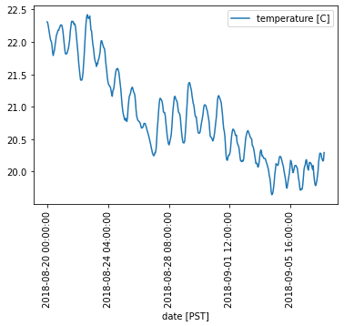

```python
# Import Pandas module
import pandas as pd

# Define URL buoy
URL = 'http://columbia.loboviz.com/cgi-data/nph-data.cgi?x=date&y=temperature&min_date=20180820&max_date=20180907&node=32&data_format=text'

# Read data from buoy
buoy_data = pd.read_csv(URL,sep='\t',header=2)

# Do quick plot
buoy_data.plot(x='date [PST]',y='temperature [C]', rot=90)
```

To see the plot you just made, click on the "Plot" tab (beside your "Variable explorer"). See below...

[figure not shown]

### Code Explanation:

#### Line 1:

```python
import pandas as pd
```

Here we imported the `pandas` module, which is a fantastic data analysis library (learn more: http://pandas.pydata.org/ ). Note that we also "nicknamed" the module `pd` so that we don't have to write the long name "pandas" before each function.

#### Line 2:

```python
URL = 'http://columbia.loboviz.com/cgi-data/nph-data.cgi?x=date&y=temperature&min_date=20180820&max_date=20180907&node=32&data_format=text'
```

Here we assigned a string to a new variable that we decided to call `URL`. Note that if you just copy-paste the full url into a browser, you would actually display the data in your browser as text. Of course, the tricky part is to figure out what url to query?... It is not hard, but I'll show you how to do this in another lab.

#### Line 3:

```python
buoy_data = pd.read_csv(URL,sep='\t',header=2)
```

This line queries the server, **downloads the data** and puts it into a new variable that we called `buoy_data`. Below is the breakdown:

So, we used 2 arguments in this example (i.e. `sep` and `header`), but **how do we know what arguments are available and how to use them?**

**ANSWER:** Google the function name (i.e. Google: `pd.read_csv`)

Note that the output, `buoy_data`, is a pandas DataFrame object. We'll talk more about this below.

#### Line 4:

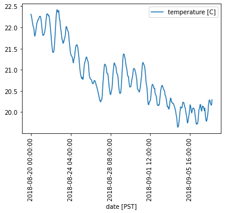

```python
buoy_data.plot(x='date [PST]',y='temperature [C]', rot=90)
```

Here we applied the method **plot** to the pandas DataFrame object **buoy_data**. The output is a plot!

### Inspecting your code

Before we do anything with our newly downloaded data, lets take a minute to examine our code...

In the code above (i.e. Real-life case study 1: Downloading real-time data from an oceanographic buoy in Oregon)...  
...What is: URL

In the code above (i.e. Real-life case study 1: Downloading real-time data from an oceanographic buoy in Oregon)...  
...What is: pandas

In the code above (i.e. Real-life case study 1: Downloading real-time data from an oceanographic buoy in Oregon)...  
...What is: pd.read_csv

In the code above (i.e. Real-life case study 1: Downloading real-time data from an oceanographic buoy in Oregon)...  
...What is: buoy_data

In the code above (i.e. Real-life case study 1: Downloading real-time data from an oceanographic buoy in Oregon)...  
...What is: .plot

### Inspecting buoy_data:

Making a quick plot is useful, but we likely also want to look at the actual data. Lets start by inspecting what type of object is **buoy_data**

```python
type(buoy_data)
```

```
pandas.core.frame.DataFrame
```

As I said above, **buoy_data**, is a pandas DataFrame object (a *pandas.core.frame.DataFrame* to be specific). It is very similar to the core DataFrame in R. If you are not familiar with R, a good way to describe a pandas DataFrame is a table like an Excel spread-sheet, with rows and columns.

To actually take look into **buoy_data**, simply :

```python
buoy_data
```

|  | date [PST] | temperature [C] |
| --- | --- | --- |
| 0 | 2018-08-20 00:00:00 | 22.31 |
| 1 | 2018-08-20 01:00:00 | 22.29 |
| 2 | 2018-08-20 02:00:00 | 22.24 |
| 3 | 2018-08-20 03:00:00 | 22.18 |
| 4 | 2018-08-20 04:00:00 | 22.13 |
| ... | ... | ... |
| 451 | 2018-09-07 19:00:00 | 20.21 |
| 452 | 2018-09-07 20:00:00 | 20.18 |
| 453 | 2018-09-07 21:00:00 | 20.16 |
| 454 | 2018-09-07 22:00:00 | 20.18 |
| 455 | 2018-09-07 23:00:00 | 20.29 |

456 rows × 2 columns

```python
buoy_data.head()
```

|  | date [PST] | temperature [C] |
| --- | --- | --- |
| 0 | 2018-08-20 00:00:00 | 22.31 |
| 1 | 2018-08-20 01:00:00 | 22.29 |
| 2 | 2018-08-20 02:00:00 | 22.24 |
| 3 | 2018-08-20 03:00:00 | 22.18 |
| 4 | 2018-08-20 04:00:00 | 22.13 |

After you ran the following statement  
buoy_data.head()  
What is the temperature (C) in the first record?

Similarly you can show only the end of the table by applying the **.tail** method to the **buoy_data** object:

```python
buoy_data.tail()
```

|  | date [PST] | temperature [C] |
| --- | --- | --- |
| 451 | 2018-09-07 19:00:00 | 20.21 |
| 452 | 2018-09-07 20:00:00 | 20.18 |
| 453 | 2018-09-07 21:00:00 | 20.16 |
| 454 | 2018-09-07 22:00:00 | 20.18 |
| 455 | 2018-09-07 23:00:00 | 20.29 |

After running the following statement  
buoy_data.tail()  
What is the last temperature in your table?

Instead of referring to the entire table (**buoy_data**), you can just refer to one column. The table is a Python dictionary where the "header" of each column is the dictionary key which will return the entire column. For example, to refer ONLY to the temperature column, :

```python
buoy_data['temperature [C]']
```

```
0      22.31
1      22.29
2      22.24
3      22.18
4      22.13
       ...
451    20.21
452    20.18
453    20.16
454    20.18
455    20.29
Name: temperature [C], Length: 456, dtype: float64
```

Lets calculate the average temperature by applying the **.mean** method only to the 'temperature [C]' column:

```python
buoy_data['temperature [C]'].mean()
```

```
20.861206140350866
```

Similarly, you can calculate the minimum, maximum, median, standard deviation, mode, etc...

```python
buoy_data['temperature [C]'].min()
```

```
19.64
```

```python
buoy_data['temperature [C]'].max()
```

```
22.42
```

```python
buoy_data['temperature [C]'].median()
```

```
20.74
```

```python
buoy_data['temperature [C]'].std()
```

```
0.731239256140188
```

```python
buoy_data['temperature [C]'].mode()
```

```
0    20.12
dtype: float64
```

## Real-life case study #2: Downloading real-time data from a Glider (Autonomous Underwater Vehicle) from Nova Scotia

| Slocum Glider | Current deployment |
| --- | --- |

The code below pulls data from a glider currently deployed off the coast of Nova Scotia (http://gliders.oceantrack.org/). The code also does a simple quality control and makes a rough depth-vs-time scatter plot.

In *Spyder* open a new file, name it glider.py, copy-paste the code below and click .

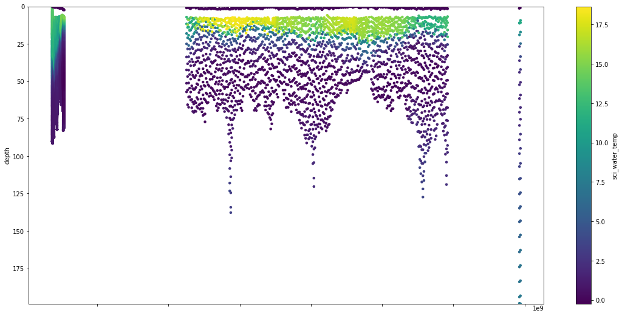

```python
# Import Pandas module
import pandas as pd

# Define URL of glider
URL = 'http://gliders.oceantrack.org/data/live/otn201_sci_water_temp_live.csv'

# Read data from glider server
glider_data = pd.read_csv(URL,sep=',')

# Quality Control: Filter out data above 40oC and below -8oC
glider_data = glider_data[(glider_data.sci_water_temp < 40) & (glider_data.sci_water_temp > -8)]

# Make a scatter plot
glider_data.plot.scatter('unixtime',
                         'depth',
                         c='sci_water_temp',
                         marker='o',
                         edgecolor='none',
                         cmap='viridis',
                         ylim=[glider_data['depth'].max(),0],
                         figsize=[19,9])
```

Take a look inside `glider_data`

```python
glider_data.head()
```

|  | unixtime | lat | lon | depth | sci_water_temp |
| --- | --- | --- | --- | --- | --- |
| 0 | 1.469369e+09 | 48.337975 | -64.175423 | 0.000000 | 0.0000 |
| 1 | 1.469369e+09 | 48.337438 | -64.171928 | 90.088686 | 0.9753 |
| 2 | 1.469369e+09 | 48.337437 | -64.171921 | 90.123090 | 0.9856 |
| 3 | 1.469369e+09 | 48.337436 | -64.171909 | 90.179436 | 0.9772 |
| 4 | 1.469369e+09 | 48.337435 | -64.171897 | 90.240740 | 0.9767 |

Tough question: What is the maximum depth recorded in this dataset? Hint: Apply the **.max** method on the "depth" column.

What is the **maximum** depth recorded in glider_data?

More tough questions:

What is the **maximum** water temperature recorded in the "sci_water_temp" column within glider_data?

What is the **minimum** water temperature recorded in the "sci_water_temp" column within glider_data?

How many records are in the "sci_water_temp" column within glider_data?

## Installing new modules

[figure not shown]

Before we do our last "Real-life case study", we need to install 3 modules that do not come pre-installed with `Anaconda`. There are several ways to install Python modules and libraries, here we will use `conda`. Note that normally you only need to install a module once (it will remain installed until you manually remove it). However, because the lab computers are wiped out clean every night, you may need to install the same module several times during this course. Lets install 3 modules (i.e. netcdf4, cartopy and cmocean). I'll explain what these modules do later.

- Open the by typing in the Window's Task Bar the term **"Anaconda Promt"** (in Mac, you can search in the Launchpad for "Terminal")
- To install `netcdf4`, type in the *Terminal*:

  conda install -c anaconda netcdf4
- Click [Enter]
- If it asks you "are you sure?", type "y" and click [Enter] again.
- To install `cartopy`, type in the *Terminal*:

  conda install -c conda-forge cartopy
- Click [Enter]
- If it asks you "are you sure?", type "y" and click [Enter] again.
- To install `cmocean`, type in the *Terminal*:

  conda install -c conda-forge cmocean
- Click [Enter]
- If it asks you "are you sure?", type "y" and click [Enter] again.

Done! The new modules are now installed (again, I'll explain how to use these new modules below).

## Real-life case study #3: Downloading Satellite data from an ERDDAP server

[figure not shown]

ERDDAP is a data server that simplifies the download of subsets of scientific datasets to make graphs and maps (We'll learn more about ERDDAP in another lab).

Here we will be using one of NOAA's ERDDAP: https://coastwatch.pfeg.noaa.gov/erddap/info/index.html?page=1&itemsPerPage=2000

If you haven't installed `netcdf4`, `catopy` and `cmocean` yet.... take a look at the section above.

In Spyder's *Editor* open a new file and save it as `satellite.py`. Copy-paste the code below and click

Note that the code below is pretty much "the real deal". It is as complicated as it gets with Python, yet it is just a series of statements declaring variables and applying functions and methods. Note that, **by convention**, at the top of the file you import all the modules you need.

```
<cartopy.mpl.feature_artist.FeatureArtist at 0x1f0d56a0100>
```

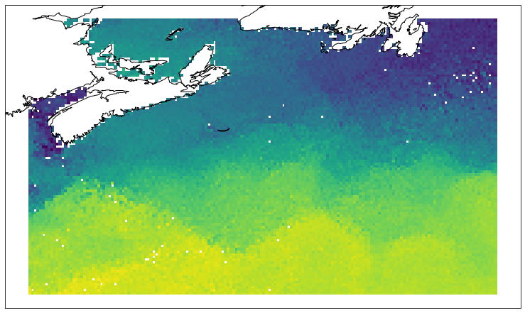

```python
import urllib.request
import netCDF4
import numpy as np
import matplotlib.pyplot as plt
import cartopy.crs as ccrs
import cartopy.feature as cfeature
import cmocean

# Define the spatial and temporal box of interest
year = 2015
month = 8
minlat = 38
maxlat = 48
minlon = -67
maxlon = -50
isub = 0.5

# Make "minday" and "maxday" strings by concatenating several pieces
minday = str(year)+'-'+str(month).zfill(2)+'-11T12:00:00Z'
maxday = str(year)+'-'+str(month+1).zfill(2)+'-11T12:00:00Z'

# Create the URL
base_url='http://coastwatch.pfeg.noaa.gov/erddap/griddap/erdAGsstamday_LonPM180.nc?'
query='sst[('+minday+'):'+str(isub)+':('+maxday+')][(0.0):'+str(isub)+':(0.0)][('+str(minlat)+'):'+str(isub)+':('+str(maxlat)+')][('+str(minlon)+'):'+str(isub)+':('+str(maxlon)+')]'
url = base_url+query

# Download data and store it in a NetCDF file
filename='satellite_data_tempfile.nc'
urllib.request.urlretrieve (url, filename)

# open NetCDF data
nc = netCDF4.Dataset(filename)
ncv = nc.variables

# Extract variables of interest from inside the NetCDF file
lon = ncv['longitude'][:]
lat = ncv['latitude'][:]
sst = ncv['sst'][0,0,:,:]

# Make grids of lats and lons for later use to make maps
lons, lats = np.meshgrid(lon,lat)


#%% Create map (PlateCarree Projection)
fig = plt.figure(figsize=(13,13)) # Create figure
ax = plt.axes(projection=ccrs.PlateCarree()) # Create axis within figure (with projection)
ax.pcolormesh(lons, lats, sst, transform=ccrs.PlateCarree()) # Add colormap to axis (specifying projection of data)
ax.coastlines(resolution='10m') # Add coastline to axis
```

Take a look at the generated map. You can see the Gulf Stream in the south (bottom of the graph), which has temperatures in excess of 25$^\circ$C. You can also see that in the Bay of Fundy (Nova Scotia) the temperature is cold (about 13$^\circ$C), likely because the extreme tides cause a lot of vertical mixing which brings cold water to the surface.

What do you think is the average temperature in the whole map?

Luckily this is easy to find by applying the **.mean** method to out Sea Surface Temperature data (sst):

```python
sst.mean()
```

```
21.849518880725444
```

Lets see if you can figure out what are the minimum and the maximum temperatures is sst.

```python
sst.min()
```

```
10.875
```

What is the **minimum** recorded Sea Surface Temperature in the sst data?

What is the **maximum** recorded Sea Surface Temperature in the sst data?

Lets do another map, this time using a "Lamber Conformal Conic Projection". Luckily, you can use the same data (i.e. no need to download data again), and simply create the new map with the new projection.

In this map I added some extra labels, colorbar and shadeRelief.

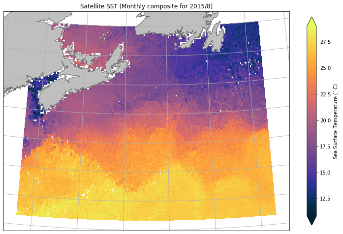

```python
import matplotlib.pyplot as plt

#%% Create map (LambertConformal Projection)
# Create figure
fig = plt.figure(figsize=(13,13))
# Create axis within figure (with projection)
ax = plt.axes(projection=ccrs.LambertConformal(central_longitude=(maxlon+minlon)/2, central_latitude=(maxlat+minlat)/2))
# Add colormap to axis (specifying projection of data)
cs = ax.pcolormesh(lons, lats, sst, cmap=cmocean.cm.thermal, transform=ccrs.PlateCarree())
# Add colorbar
cbar = fig.colorbar(cs, shrink=0.6, orientation='vertical', extend='both')
# Add legend to colorbar
cbar.set_label('Sea Surface Temperature ($^\circ$C)')
 # Add land to axis
ax.add_feature(cfeature.NaturalEarthFeature(category='physical', scale='10m',facecolor='none', name='coastline'),
               edgecolor='#666666', facecolor='#bfbfbf')
# Add gridlines to axis
ax.gridlines()
# Add title to figure
plt.title('Satellite SST (Monthly composite for '+str(year)+'/'+str(month)+')')
```

We will have a more in depth Lab about making maps with Cartopy. In the mean time, feel free to explore other projections and make some extra maps. Here are some Galleries:

https://scitools.org.uk/cartopy/docs/latest/crs/projections.html

https://scitools.org.uk/cartopy/docs/latest/gallery/index.html

From the code above... which of the following are **"functions"** or **"methods"**? Note that these **"functions"** or **"methods"** have fixed names, the coder has no choice but to use the correct **"function"** or **"method"** names.

From the code above... which of the following are **"variables"**? Note that these **variables** have names that the coder chose (e.g. a coder can write **a** = 1 ... or **b** = 1 ... or **alpha** = 1 ... or **my_variable** = 1).

From the code above... in the line  
fig = plt.figure(figsize=(13,13)) What is **fig**?

From the code above... in the line  
fig = plt.figure(figsize=(13,13)) What is **plt.figure**?

From the code above... in the line  
cbar = fig.colorbar(cs, shrink=0.6, orientation='vertical', extend='both') ) What is **.colorbar**?

# **This is the end of lab**

Code below is for formatting of this lab. Do not alter!

```python
# Loads css file and applies it to lab HTML
from IPython.core.display import HTML
def css():
    style = open("../css/custom.css", "r").read()
    return HTML(style)
css()
```